# Chill portions and yield

Katja Schiffers<sup>a</sup>, Cory Whitney<sup>a</sup>, Eduardo Fernandez<sup>a</sup> and Eike Luedeling<sup>a</sup> <sup>a</sup>INRES-Horticultural Sciences, University of Bonn, Auf dem Huegel 6, 53121 Bonn, Germany

# NOTES

Often data is limited when assessing the relationship between climate change and yield. Despite this lack of data we are nevertheless required to make assessments and produce useful projections for farmers and decision makers. Perhaps this data limitation does not need to hinder our abilities to assess the relationships between temperature and yield. For course assessments a lot of data may not be necessary. Here we show a method whereby we can embrace the inherint uncertainty in such assessments to overcome the need for preciseness. After all far into the future we have no data. We necesarily have uncertainty in our model forecasts. We use the pasitR package (Schiffers et al. 2018) in the R programming language (R Core Team 2019).

Create random chill and yield data using `sample()`.

```r
chill <- sample(x = 1:50, size = 20, replace = TRUE)
yield <- sample(x = 1000:5000, size = 20, replace = TRUE)
```

Using `chillscatter()` create a chill portions (x) and yield (y) scatter plot with associated and estimated densities with loess smooth linear fits density curves. Plot made with the `scatter.hist()` function in the `plyr()` package (Wickham 2019).

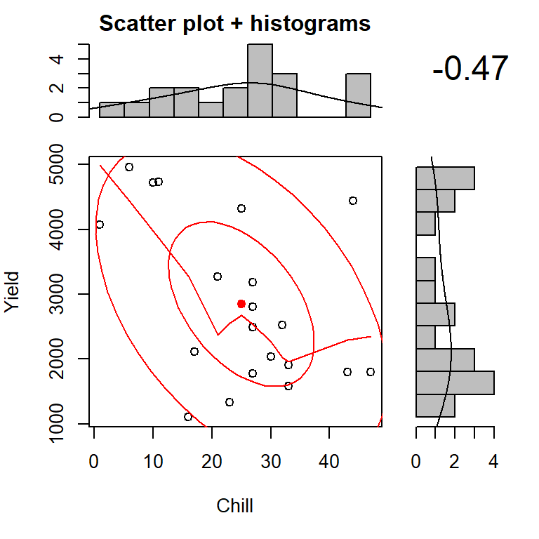

```
## [1] "Chill (x) and yield (y) scatter plot with associated and estimated densities."
```

```r
pasitR::chillscatter(chill, yield)
```

Use `chillkernel()` or another type of graphical representation of the same relationship. `chillkernel()` performs a two-dimensional kernel density estimation for yield and chill using the `kde2d()` function in the `MASS()` package (Ripley 2019). The function produces a matrix of the estimated density (z) of yield (y) and chill (x). As the density function restricts the shape of the kernel to a bivariate normal kernel, it looks slightly different compared to the scatter plot estimates above.

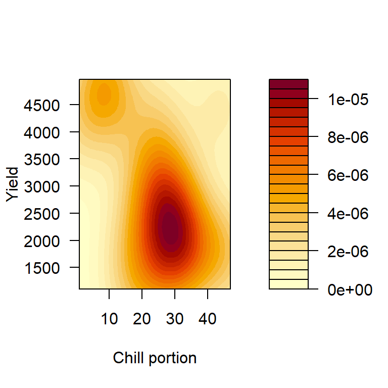

```
## [1] "Density surface plot of chill portions (x) and yield (y)."
```

```r
pasitR::chillkernel(chill, yield)
```

`chillkernel()` shows a density surface plot of chill portions (x) and yield (y). The legend shows the value for the estimated density (z). The plot is made with the `filled.contour()` function of the `graphics()` package (R Core Team 2019).

In `chillkernel()` the density (z) over the entire plot integrates to one, and therefore represents the relative probability of an observation (yield along y-axis) given a specific chill portion (along x-axis).

## Estimated yield given the expected chill

`chillkernelslice()` calculates the estimated yield given the expected chill, based on a slice of ‘z’ from the Kernel density calcualted with `chillkernel()`. The `expectedchill` parameter is set to 30.

[figure not shown]

```
## [1] "Estimated yield given expected chill."
```

```r
pasitR::chillkernelslice(chill, yield, expectedchill = 30)
```

## Chill portion intervals

`chillviolin()` determines different possible chill portion intervals by calculating the optimal interval width for chill portions using the `IQR()` function in the `stats()` package, after the Freedman-Diaconis rule (IQR = interquartile range) (R Core Team 2019). `Optimal interval width for our sample = 2 * interquartile range for our sample / (total number of observations for the interquartile range for our sample)^(1/3)`

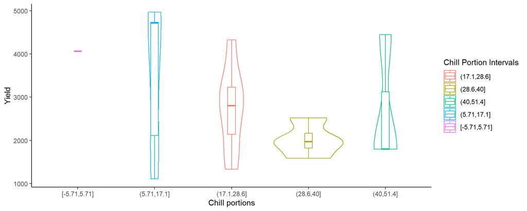

[output not shown]

```r
pasitR::chillviolin(chill, yield)
```